# Pretty Plotting in ggplot2

## Overview

Throughout this semester we have made a wide variety of plots, looking at everything from scatter plots to boxplots to histograms. We have classically focused mainly on the content of said plots, and not particularly concerned ourselves with making sure they looked nice and conveyed the ideas in a clear and aesthetically pleasing manner. That is all well and good when we are using them only for personal use, but the instances will arise (and arise often!) where we need to present work to peers, administration, or bosses, and in those situations we need a method to produce clear, well-labeled and insightful plots. The base plotting packages that we have been using in R are capable of some improved graphics, but ultimately there is a better method: ggplot2.

## Setup

You almost certainly do not already have the `ggplot2` library installed on your system, and will need to do so before you can really get going today. This is easy however. Just run

```r
install.packages("ggplot2")
```

in the console. You will only every need to run this command *once*. It will take a minute or so probably for it to grab and setup all the necessary files it needs. Once it is complete (and you get a prompt back and text stops flying across the screen), you can proceed.

Whenever you want to *use* `ggplot2`, you will need to load the library. Since you’ve already installed it, this is as easy as running

```r
library(ggplot2)
```

## The Basics

If we are going to be plotting, we need to grab ourselves some data to work with! Here we will grab a dataset that is provided with the `ggplot2` package, which provides housing sales data from the state of Texas from 2000 through 2015. To load it, you should just be able to do:

```r
data(txhousing)
```

and you’ll see the `txhousing` dataframe show up in your environment.

1. Take am moment to look the dataset over. What does each case (row) of the dataset represent? What type of variable is date? Are there any missing values (NA’s) in the dataset?

Plotting in `ggplot2` is a little different that traditional plotting. For one, we always will pass in the entire dataframe instead of individual vectors (or columns) of the dataframe like we have done traditionally. Then we will specify what columns should represent certain aspects of the plot. The whole concept of `ggplot` in general is that you create a plot and then layer on additional aspects atop it. This gives an immense degree of flexibility in how you create a plot, and, once you grasp the basics, is rather intuitive.

Let’s try to visualize how the median house price in Texas has changed over the past 15 years. So we would like the `date` to be on the x-axis and the `median` price to be on the y-axis. In `ggplot` we would set that up as follows:

```r
ggplot(txhousing, aes(x=date, y=median))
```

where the first value we pass is the name of the entire dataframe and the second is telling `ggplot` something about the aesthetics of our plot, in this case telling it what values to use on the x and y axes. If you run this though, you will notice that you just get a blank plot! Where is all the data?!

An important aspect of `ggplot` is that it uses special geometric layers to add types of plots to an axis. In this case, we haven’t gotten any points plotted yet because we have not specified that we want points to be plotted on this graph. To do so, we add another layer to the plot, which is done simply with a + sign.

```r
ggplot(txhousing, aes(x=date, y=median)) + geom_point()
```

Now we have some points showing up! It important to note that we can change properties of those points by adjusting what goes inside of the `geom_point()` command. For instance, we could make a bunch of dark red points by using:

```r
ggplot(txhousing, aes(x=date, y=median)) + geom_point(col='darkred')
```

You can change other properties like size, shape, and alpha (transparency) in a similar fashion.

2. Create a plot of the median housing price in Texas from 2000 to 2015 where the points are larger (size 5), purple and have 10% transparency (0.1).

No good plot exists without label (including units) and a title. These can be added to `ggplot` graphs by adding a `labs` layer.

```r
ggplot(txhousing, aes(x=date, y=median)) +
  geom_point(col='darkred') +
  labs(title='Housing Prices in Texas over Time', y='Median Price (dollars)')
```

Remember that you can always use `?labs` to get more details about what types of labels might be available to you!

Finally, perhaps one of the most powerful aspects of `ggplot` is its ability to tie certain column data to different aspects of the plot. For instance, we could have the size of the point be related to the volume of the houses sold that month. Or we could have the color of the point correspond to the city. These are things that would be very difficult to do with our traditional plotting methods, and `ggplot` makes them very easy!

Whenever you want to ascribe some aspect of a plot to a column in your dataframe, you need to wrap that term in a `aes()` environment. That tells `ggplot` to change the aesthetics by looking up values in the dataframe. Here I will scale the size of the point plotted according to the `volume` of houses sold.

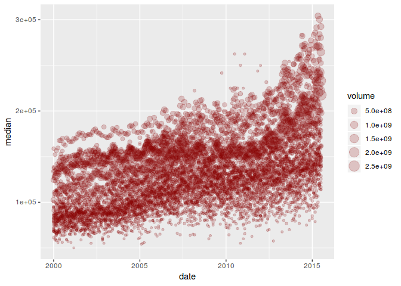

```r
ggplot(txhousing, aes(x=date, y=median)) +
  geom_point(aes(size=volume), alpha=0.2, col='darkred')
```

You’ll notice that now some of the points are tiny and others are much larger. Helpfully, `ggplot` even adds a legend automatically for you! Some plot parameters (like size) work well with numeric variables, some (like shape) work better with categorical variables and some (like color) can work with either. If you ever try to associate a property to a column that does not support it, `ggplot` will spit out a helpful error to you stating as much.

3. Create a scatter plot of the number of sales vs the number of listings. Include labels and color your points according to the median price.

## Other Plot Styles

We can use other `geom`’s to make (or layer) on different types of plots. For instance, to make a histogram of the median housing prices:

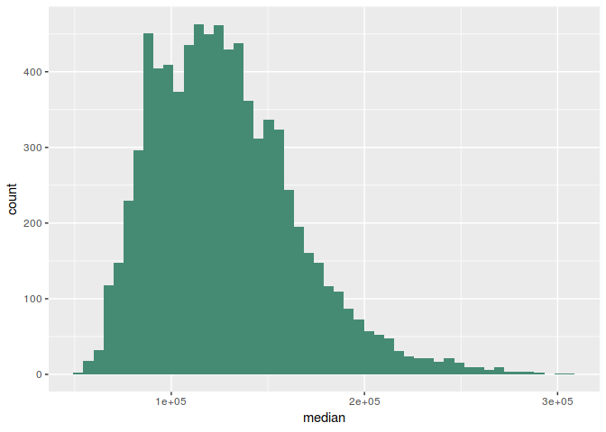

```r
ggplot(txhousing, aes(x=median)) + geom_histogram(bins=50, fill='aquamarine4')
```

And there is a similar `geom` for boxplots!

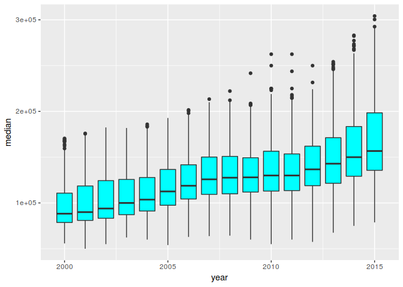

```r
ggplot(txhousing, aes(y=median)) +
  geom_boxplot(aes(x=year, group=year), fill='cyan')
```

I had to group by year here since `ggplot` generally was seeing `year` as a continuous numerical value despite having discrete intervals.

4. Does the `sales` variable seem to be normally distributed? Provide graphical evidence for your conclusion.

Remember that you can always type in `geom` and then hit tab to see all the different types of `geom`s available to you.

A few other useful tips before sending you off on your own. Like any other object in R, you can save a plot as a variable and then show it later with `print`.

```r
mybestplot <- ggplot(...)

print(mybestplot)
```

This can also be useful if you have an existing plot and want to just add another layer atop it (you can just add them). Finally, to save a plot, you can use:

```r
ggsave("Image_of_mybestplot.png", mybestplot)
```

which can be useful to then include in a paper or presentation.

## On your own

You’ll import and be visualizing the `diamonds` dataset for the below problems. This is a dataset also built into `ggplot`, so as long as you have run `library(ggplot2)` already, you can just import the dataset with `data("diamonds")`.

- Plot the price of a diamond vs it’s carat as a scatter plot. Set the color of the point according to the color of the diamond and the shape of the point according to the cut of diamond. Make sure you include a title!
- Plot a histogram of the price of diamonds. Have the fill color of the histogram be determined by the cut of the diamond. This will create a stacked histogram. Don’t forget your title!
- Create comparative boxplots comparing the prices for different colors of diamond. Give your plot some color, and as always include titles and labels.

This lab was written entirely by Jed Rembold for his IDS-138: Introduction to Applied Statistics course at Willamette University, 2019.